# Da mente ao método científico

Como linguagem, lógica, matemática, equações, experimentos e teorias transformam experiências humanas em conhecimento - das primeiras marcas à inteligência artificial em 2026

Tratado conceitual e manual de laboratório - Volume IV

11 de agosto de 2026

## Como ler este tratado

Este livro foi escrito para responder à pergunta que quase nunca é ensinada de modo completo: **como uma experiência, uma ideia ou uma conta se transforma em conhecimento científico sobre uma realidade que não depende apenas da opinião do pesquisador?**

A resposta curta é:

> O ser humano não olha para a natureza, “inventa uma equação” e depois prova que ela é verdadeira. Ele constrói uma cadeia pública de representações: delimita um fenômeno, define grandezas, formula hipóteses, idealiza um sistema, escolhe ou desenvolve matemática, deriva consequências, cria procedimentos de medição, compara previsões e dados, investiga erros e submete tudo à crítica e à replicação.

Essa cadeia possui dois controles diferentes:

1. **Controle lógico-matemático:** a conclusão realmente decorre das definições, axiomas, premissas e equações?
2. **Controle empírico:** a estrutura assim construída corresponde suficientemente ao comportamento do sistema real, no domínio examinado e dentro das incertezas?

Uma demonstração pode responder ao primeiro controle sem responder ao segundo. Uma teoria fisicamente falsa pode produzir matemática impecável. Um experimento favorável pode responder ao segundo sem provar que a teoria é a única explicação possível. Compreender essa diferença resolve grande parte da confusão em torno das palavras *prova*, *teorema*, *lei*, *hipótese* e *teoria*.

Este volume não substitui o roteiro bibliográfico do Volume III. Ele explica conceitualmente o que aquele roteiro organizava. A data de corte historiográfica e tecnológica é **11 de agosto de 2026**. Os números entre colchetes são links para as referências completas.

## 1. Antes dos conceitos: mente, mundo e representação

### 1.1 O mundo não chega à mente em forma de equação

Uma pedra cai. Esse acontecimento não chega ao observador já dividido em “massa”, “posição”, “tempo”, “velocidade” e “aceleração”. O sistema nervoso recebe luz, som, pressão, equilíbrio e outras alterações. A mente organiza parte delas como um objeto persistente, uma trajetória e uma sequência temporal. A linguagem permite separar, nomear e comunicar aspectos dessa experiência. Instrumentos ampliam, estabilizam e transformam o que pode ser observado.

Por isso, devem ser distinguidas quatro coisas:

- **acontecimento:** a mudança física que ocorre;
- **experiência:** como um organismo vivencia ou detecta a mudança;
- **descrição:** o enunciado produzido sobre o acontecimento;
- **modelo:** a representação seletiva usada para explicar, calcular ou prever.

Não é preciso negar a existência da pedra para reconhecer que “corpo pontual sob aceleração constante” é uma construção. O modelo não é a pedra; é uma ferramenta que preserva relações julgadas relevantes e omite outras. A filosofia dos modelos mostra que modelos científicos podem ser objetos materiais, diagramas, narrativas, equações, estruturas matemáticas ou combinações dessas formas. Eles representam um *sistema-alvo* sob propósitos e idealizações definidos. 23 63 64

### 1.2 Realidade objetiva, experiência subjetiva e acordo intersubjetivo

| Conceito | Definição de trabalho | Exemplo | O que não significa |
| --- | --- | --- | --- |
| **Realidade objetiva** | Aquilo cuja existência ou comportamento não depende apenas da crença de um indivíduo específico. | A pedra acelera mesmo se o observador calcular errado. | Uma “visão de lugar nenhum” totalmente livre de conceitos. |
| **Experiência subjetiva** | Estado acessível em primeira pessoa, ligado ao ponto de vista do sujeito. | Dor, vertigem, aparência de uma cor. | Algo necessariamente falso ou sem causas físicas. |
| **Intersubjetividade** | Acordo obtido por várias pessoas mediante linguagem, regras e procedimentos compartilhados. | Vários laboratórios obtêm medidas compatíveis. | Garantia automática de verdade; grupos inteiros podem errar. |
| **Objetividade epistêmica** | Grau em que métodos e resultados resistem a preferências individuais, vieses e mudanças de observador competente. | Calibração, cegamento, dados públicos e replicação. | Ausência total de valores, escolhas ou pressupostos. |
| **Realidade social** | Fatos dependentes de práticas coletivas, mas não da vontade isolada de uma pessoa. | Moeda, universidade, autoria, lei jurídica. | Irrealidade; instituições têm efeitos objetivos. |

Em ciência, “objetivo” funciona melhor como um **ideal graduável** do que como selo absoluto. Uma medição se torna mais objetiva quando o procedimento é especificado, o instrumento é calibrado, as incertezas são declaradas, diferentes analistas podem reproduzir o resultado e críticas relevantes são incorporadas. A objetividade pertence não apenas ao indivíduo, mas a práticas comunitárias de correção. 24 33

Ver “com os próprios olhos” não é o critério decisivo. Ninguém vê diretamente um elétron, a curvatura do espaço-tempo ou a temperatura média de uma estrela. Vemos marcas, imagens, espectros e números produzidos por cadeias instrumentais. A observação científica depende de conhecimentos sobre o instrumento, o ambiente e o fenômeno. Isso não torna qualquer interpretação igualmente boa: calibração, controles independentes, previsões e convergência entre instrumentos restringem as interpretações. 25 26 35

### 1.3 Informação, conhecimento e verdade

Uma anotação pode conter informação sem constituir conhecimento. Para funcionar como conhecimento científico, uma afirmação precisa estar ligada a razões e procedimentos que outras pessoas possam examinar. Em termos práticos:

- **dado:** registro produzido por um procedimento;
- **evidência:** dado considerado relevante para comparar afirmações;
- **crença:** atitude de aceitar uma proposição;
- **justificação:** razões oferecidas para essa aceitação;
- **conhecimento científico:** afirmação bem sustentada, pública, falível e integrada a práticas de investigação;
- **verdade:** aquilo que a afirmação acerta sobre seu objeto, conceito mais forte do que consenso ou utilidade.

Uma tabela não “fala”. O mesmo número pode ser evidência para perguntas diferentes, ou não ser evidência alguma se o processo que o produziu for desconhecido. Dados tornam-se evidência dentro de uma relação entre pergunta, modelo, desenho, medição e inferência.

## 2. Do gesto ao número: o que podemos dizer sobre a pré-história

### 2.1 A linguagem veio primeiro?

É razoável supor que formas ricas de comunicação oral precederam a escrita por um intervalo enorme. Porém, fala não fossiliza. A data, a arquitetura e até a espécie em que surgiu uma linguagem plenamente humana permanecem questões abertas. Reconstruções combinam anatomia, genética, arqueologia, cognição comparada e linguística, sem produzir uma biografia do “primeiro falante”. 1

Portanto, a sequência “o Homo sapiens começou a falar, depois contou histórias, depois escreveu livros” é uma **narrativa pedagógica plausível em escala ampla**, não uma cronologia documentada de indivíduos. Gestos, imitação, vocalização, memória social, técnica, classificação e quantidade provavelmente se desenvolveram em interação. Além disso, capacidades numéricas aproximadas não pertencem exclusivamente ao *Homo sapiens*: outros animais discriminam quantidades; o problema arqueológico é explicar a passagem de sensibilidades quantitativas para números exatos, sinais e procedimentos culturais. 2

### 2.2 Marcas em ossos não são livros de aritmética transparentes

Artefatos paleolíticos contêm séries de incisões. Algumas podem ter registrado quantidades, ciclos, acontecimentos ou gestos técnicos. Entretanto, uma sequência de riscos não informa por si mesma se representava luas, animais, dívidas, decoração ou aderência de uma ferramenta. Pesquisadores usam microscopia, ordem de produção, agrupamentos, contexto arqueológico e comparações culturais para avaliar hipóteses. A interpretação matemática é possível, não automática. 2 3

Essa cautela já ensina método científico: um objeto admite modelos rivais; o padrão visual sugere hipóteses; evidências independentes precisam diferenciá-las. Não há fundamento para nomear um “homem das cavernas inventor da matemática”.

### 2.3 Contar não é apenas reconhecer “muitos”

O número exato exige uma operação cultural sofisticada. Para dizer que há sete pedras, uma comunidade precisa estabilizar alguma forma de:

1. **individuar:** decidir o que conta como uma unidade;
2. **corresponder:** associar cada objeto a um gesto, palavra, marca ou ficha;
3. **ordenar:** manter uma sequência estável de sinais;
4. **cardinalizar:** compreender que o último termo expressa a quantidade do conjunto;
5. **conservar:** reconhecer que a quantidade permanece apesar de rearranjos;
6. **registrar ou comunicar:** permitir que outra pessoa recupere a contagem.

O passo decisivo não foi enxergar um “sete” flutuando sobre sete pedras. Foi criar práticas que tornam conjuntos diferentes equivalentes quanto à quantidade. Depois que “sete” se separa das sete pedras, dos sete dias e dos sete animais, ele funciona como objeto abstrato.

### 2.4 Fichas, escrita e administração

No antigo Oriente Próximo, fichas de argila foram usadas para registrar bens e medidas durante milênios. A hipótese influente de Denise Schmandt-Besserat liga esses sistemas de contabilidade à formação da escrita cuneiforme. O percurso exato é debatido em detalhes, mas a evidência mostra que quantidade, registro, administração e escrita estiveram profundamente conectados. 4

Na Mesopotâmia e no Egito, os primeiros textos matemáticos preservados já apresentam tradições maduras: tabelas, sistemas de medida, repartições, áreas, volumes e problemas administrativos. Ahmes, copista do Papiro Rhind, é um dos primeiros praticantes nomeados preservados, mas copiou material anterior; não inventou a matemática nem a equação. 5 6 7 8 9

## 3. A matemática foi inventada ou descoberta?

### 3.1 A pergunta contém várias perguntas

Quando alguém pergunta se a matemática foi inventada ou descoberta, pode estar perguntando:

- os **símbolos** foram inventados?
- os **conceitos** são criações mentais ou correspondem a entidades abstratas independentes?
- uma vez aceitos certos axiomas, suas **consequências** são escolhidas ou descobertas?
- as **regularidades matemáticas da natureza** existiam antes de nós?

Misturar essas perguntas cria falsos dilemas.

### 3.2 Quatro famílias de respostas

| Posição | Tese aproximada | Força | Dificuldade |
| --- | --- | --- | --- |
| **Platonismo** | Números, conjuntos ou estruturas existem de modo abstrato; matemáticos os descobrem. | Explica a sensação de necessidade e independência. | Como seres físicos conhecem objetos não espaciais? |
| **Formalismo/dedutivismo** | Matemática investiga consequências de sistemas formais e regras. | Torna explícitos axiomas e inferências. | Pode parecer reduzir significado a manipulação simbólica. |
| **Nominalismo/ficcionalismo** | Não é necessário admitir objetos abstratos independentes. | Evita ontologia abstrata robusta. | Precisa explicar a indispensabilidade matemática na ciência. |
| **Estruturalismo** | A matemática trata principalmente de posições e relações em estruturas. | Aproxima prática, invariância e aplicação. | Há versões rivais sobre o que são estruturas. |

Não existe consenso filosófico final. As posições possuem versões sofisticadas e não podem ser reduzidas a “a matemática é real” contra “a matemática é inventada”. 17 18 19 20

### 3.3 A resposta operacional mais útil

Para aprender ciência, use esta síntese:

> **Inventamos** notações, definições, representações e escolhas axiomáticas; **descobrimos** consequências que não controlamos livremente depois de fixadas essas escolhas; e **investigamos empiricamente** se alguma estrutura matemática representa relações do mundo.

O símbolo “7”, a palavra “sete” e sete traços são convenções. Mas não é convenção que, na aritmética usual, um conjunto de sete elementos não possa ser colocado em correspondência um-a-um com um conjunto de seis sem que algo sobre. A aplicação a sete pedras exige ainda decidir o que conta como pedra, onde o conjunto começa e se algum objeto foi ocultado.

Essa síntese não encerra o debate metafísico. Ela separa tarefas: construção de linguagem, descoberta matemática e validação empírica.

## 4. A arquitetura do raciocínio: termos, proposições e argumentos

### 4.1 A unidade básica não é o número, mas a afirmação

Antes de entender prova ou teoria, é preciso entender um argumento.

| Termo | Significado | Exemplo |
| --- | --- | --- |
| **Conceito** | Conteúdo usado para distinguir ou relacionar. | Pedra, massa, primo. |
| **Termo** | Expressão que designa um conceito ou objeto. | “Aceleração”. |
| **Definição** | Regra que fixa o uso de um termo em um contexto. | Velocidade média é deslocamento dividido pelo intervalo. |
| **Proposição** | Enunciado ao qual se atribui verdade ou falsidade. | “A bola percorreu 1 m.” |
| **Premissa** | Proposição usada como ponto de partida de um argumento. | “Se a aceleração é constante…” |
| **Conclusão** | Proposição que o argumento pretende sustentar. | “…então a distância depende de $t^2$.” |
| **Argumento** | Conjunto de premissas apresentadas como razões para uma conclusão. | Derivação, explicação ou inferência estatística. |
| **Inferência** | Passagem racional de certas afirmações a outra. | Dedução, indução ou abdução. |

Um argumento não é uma briga. É uma estrutura que pode ser avaliada quanto à forma e ao conteúdo. Uma introdução contemporânea clara está em Gensler; a passagem para provas formais pode ser feita com Hammack e Velleman. 13 14 15

### 4.2 Dedução, indução e abdução

**Dedução:** se as premissas forem verdadeiras e a forma for válida, a conclusão não pode ser falsa.

1. Se $a$ é constante e $v(0)=0$, então $v(t)=at$.
2. Neste modelo, $a$ é constante e $v(0)=0$.
3. Logo, $v(t)=at$.

**Indução:** padrões observados sustentam generalizações ou previsões, sem necessidade lógica. Cem descidas da esfera podem sustentar uma regularidade, mas não contêm todas as descidas possíveis.

**Abdução:** escolhe-se a melhor explicação disponível para um conjunto de evidências. Uma aceleração aproximadamente constante pode explicar simultaneamente a forma do gráfico e várias relações entre tempos e distâncias.

A ciência combina as três. Deduz previsões de modelos, usa dados para inferir parâmetros e generalizar, e compara explicações rivais. Reduzir ciência a “indução” ou a “falsificação” perde parte da prática. 28 29 30

### 4.3 Validade, verdade e solidez

Considere:

1. Todos os objetos pesados caem mais rápido que os leves.
2. A esfera A é mais pesada que B.
3. Logo, A cai mais rápido que B.

A forma pode ser válida, mas a primeira premissa pode ser falsa nas condições relevantes. Um argumento **sólido** exige forma válida e premissas verdadeiras. Na ciência, estabelecer as premissas envolve observação, medição, teorias auxiliares e delimitação de domínio.

### 4.4 A lógica surgiu antes da matemática?

Não em um sentido histórico simples. Práticas de contagem e geometria são muito anteriores aos tratados de lógica. O que ocorreu na Grécia antiga foi uma nova articulação entre argumentação, diagramas, demonstração e organização do conhecimento. Aristóteles sistematizou formas de inferência e uma teoria da demonstração científica; Euclides organizou a geometria a partir de definições, postulados, noções comuns e proposições demonstradas. 10 11 12

A lógica formal não foi uma escada que a humanidade terminou de subir antes de começar matemática. Algoritmos, diagramas e justificações desenvolveram-se em tradições diferentes. A apresentação axiomática grega foi uma transformação histórica da prova, não o nascimento de todo raciocínio matemático.

## 5. Axioma, teorema e prova: o que exatamente é demonstrado

### 5.1 O pequeno sistema chamado matemática dedutiva

Uma teoria matemática organizada contém:

- **termos primitivos:** expressões não definidas por termos ainda mais básicos;
- **definições:** introduzem conceitos precisos;
- **axiomas ou postulados:** afirmações assumidas como pontos de partida;
- **regras de inferência:** movimentos lógicos permitidos;
- **teoremas:** proposições obtidas por uma cadeia aceita de inferências;
- **lemas:** teoremas auxiliares;
- **corolários:** consequências relativamente imediatas;
- **conjecturas:** proposições ainda não demonstradas nem refutadas;
- **contraexemplos:** casos que refutam afirmações universais.

Um axioma não é necessariamente uma verdade evidente sobre toda realidade. É um compromisso de um sistema. Geometrias euclidianas e não euclidianas mostram que sistemas diferentes podem adotar estruturas diferentes. O significado físico de uma geometria usada para descrever espaço-tempo é uma questão adicional.

### 5.2 O que uma prova garante

Uma prova garante algo da forma:

$$\text{axiomas + definições + premissas} \quad \Longrightarrow \quad \text{conclusão}.$$

Ela não garante sozinha:

- que os axiomas descrevem o universo;
- que a idealização é adequada à pedra real;
- que o instrumento mede a grandeza pretendida;
- que não houve erro ao inserir números;
- que o domínio de aplicação foi respeitado.

É por isso que um teorema matemático pode ser verdadeiro em seu sistema e não descrever um fenômeno particular. Provas também são práticas históricas: diagramas, símbolos, padrões de rigor e comunidades determinam quais passos precisam ser explicitados. Lakatos mostrou como conjecturas, contraexemplos e revisões participam da descoberta matemática, embora a versão final de um texto frequentemente pareça linear. 10 14 16

### 5.3 Prova formal e prova científica são expressões perigosamente parecidas

| Situação | Pergunta | Resultado apropriado |
| --- | --- | --- |
| Matemática | A conclusão decorre necessariamente das premissas? | Demonstração ou refutação por contraexemplo. |
| Experimento | Os dados concordam com uma previsão dentro da incerteza? | Corroboração, limitação ou rejeição empírica. |
| Estatística | Quão compatíveis são dados e modelos, dadas suposições? | Estimativas, intervalos, testes, probabilidades ou comparação preditiva. |
| Ciência histórica | Qual hipótese explica melhor vestígios não repetíveis? | Inferência comparativa e convergência de evidências. |

Na linguagem cotidiana, diz-se que um experimento “provou” uma teoria. Em escrita científica rigorosa, prefira: **forneceu evidência**, **corroborou uma previsão**, **foi compatível com**, **impôs limites**, **favoreceu em relação a alternativas** ou **refutou uma versão especificada**.

## 6. Equações: o que são, quando surgiram e por que Newton não as inventou

### 6.1 Expressão, igualdade, equação, identidade e função

| Forma | Tipo | O que afirma |
| --- | --- | --- |
| $3x+2$ | Expressão | Representa um valor dependente de $x$; não afirma igualdade. |
| $3x+2=11$ | Equação-problema | Procura valores de $x$ que tornam a igualdade verdadeira. |
| $(a+b)^2=a^2+2ab+b^2$ | Identidade | Vale para todos os valores admissíveis. |
| $y=f(x)$ | Definição funcional | Associa entradas e saídas segundo uma regra. |
| $F=ma$ | Lei/modelo físico | Relaciona grandezas sob interpretação e condições físicas. |
| $\partial T/\partial t=\alpha\nabla^2T$ | Equação governante | Especifica como um campo evolui localmente. |

Uma **equação** é uma afirmação de igualdade entre duas expressões. O sinal “=” não diz por que a igualdade vale, qual é seu domínio ou se ela descreve o mundo. Essas informações vêm da definição do problema, da derivação e das regras de correspondência com medições.

### 6.2 Antes dos símbolos havia problemas equivalentes a equações

Escribas babilônicos resolviam problemas que hoje reescrevemos como equações lineares e quadráticas. Seus procedimentos eram expressos em palavras, números, operações e figuras; projetar nossa notação moderna sobre eles pode esconder a maneira histórica de pensar. Portanto, **o raciocínio equivalente a resolver equações antecede o símbolo de igualdade e a álgebra simbólica**. 5 7

Em *Arithmetica*, Diophantus empregou abreviações para incógnitas e potências em problemas numéricos. Al-Khwārizmī sistematizou tipos de problemas e operações de restauração e balanceamento em uma álgebra retórica: as relações eram escritas em palavras e justificadas geometricamente. A palavra “álgebra” deriva de *al-jabr*, no título de sua obra. Nenhum deles usava exatamente a álgebra escolar moderna. 36 37

Entre os séculos XVI e XVII, a notação algébrica europeia tornou-se mais geral. François Viète distinguiu quantidades conhecidas e desconhecidas por letras; René Descartes consolidou convenções e ligou álgebra e geometria. Robert Recorde introduziu em 1557 o sinal “=” em *The Whetstone of Witte* para evitar repetir “é igual a”. A história dos símbolos mostra acumulação, competição e padronização, não uma invenção única da equação. 38 39

### 6.3 O que Newton fez

Newton não inventou a equação. Ele e Leibniz desenvolveram, independentemente e com notações diferentes, formas gerais do cálculo. Newton articulou leis de movimento e gravitação capazes de tratar queda e órbitas numa mesma estrutura matemática. No *Principia*, boa parte do argumento foi apresentada geometricamente, não na notação de cálculo dos livros atuais. 53

### 6.4 Como alguém cria uma equação sem “inventar na hora”

Uma equação científica costuma surgir por combinação de seis fontes:

1. **definições:** $v=dx/dt$ define velocidade instantânea;
2. **regularidades observadas:** dados sugerem proporcionalidade ou outra forma;
3. **princípios de conservação:** o que entra, sai ou se acumula;
4. **simetrias e invariâncias:** a descrição não deve depender de escolhas irrelevantes;
5. **mecanismos e relações constitutivas:** como materiais ou componentes respondem;
6. **aproximações:** pequenos ângulos, velocidades baixas, sistemas diluídos.

Depois, análise dimensional, casos-limite, consistência matemática, dados anteriores e comparação com modelos rivais restringem a forma. O pesquisador pode propor um termo novo, mas não possui liberdade ilimitada.

### 6.5 Exemplo 1: a pedra

Escolha um eixo vertical $y$ positivo para cima. Perto da superfície terrestre, durante uma queda curta e ignorando o ar, modele a aceleração como constante:

$$\frac{d^2y}{dt^2}=-g.$$

Essa equação não surgiu apenas de olhar. Ela reúne uma definição de aceleração, uma idealização de campo aproximadamente uniforme e conhecimento sobre gravidade. Integrando duas vezes:

$$y(t)=y_0+v_0t-\frac{1}{2}gt^2.$$

A derivação prova condicionalmente que essa trajetória segue da equação diferencial e das condições iniciais. O experimento verifica se posições medidas concordam com a trajetória dentro da resolução e dos efeitos desprezados. Em distâncias grandes, velocidades extremas ou forte resistência do ar, outro modelo é necessário.

### 6.6 Exemplo 2: o calor

A equação do calor ilustra uma construção em camadas. Primeiro, conservação local de energia relaciona a mudança da temperatura ao fluxo de calor. Segundo, a lei constitutiva de Fourier propõe que o fluxo aponta contra o gradiente de temperatura:

$$\mathbf{q}=-k\nabla T.$$

Com densidade $\rho$ e calor específico $c$, a combinação conduz a

$$\rho c\frac{\partial T}{\partial t}=k\nabla^2T
\quad\Longrightarrow\quad
\frac{\partial T}{\partial t}=\alpha\nabla^2T,
\qquad \alpha=\frac{k}{\rho c}.$$

Fourier não viu uma derivada parcial dentro de uma barra. Ele representou temperatura como um campo, usou uma relação de fluxo e desenvolveu ferramentas para resolver o problema. Condições iniciais e de contorno ainda são necessárias. A equação explica a difusão do calor porque conecta uma diferença espacial local - a curvatura do perfil de temperatura - à taxa de mudança e produz padrões quantitativos testáveis. 54 55

## 7. Por que a matemática consegue falar sobre a realidade?

### 7.1 Símbolos precisam de uma ponte semântica

Na equação da queda, $t$ só significa tempo porque existe um procedimento para produzir intervalos; $y$ só significa posição porque definimos um referencial e uma regra de medição; $g$ só adquire valor porque é estimado sob unidades e condições. A ponte contém:

- **sistema-alvo:** qual objeto ou processo real será representado;
- **grandezas:** quais propriedades são selecionadas;
- **operações de medida:** como números serão atribuídos;
- **idealizações:** o que será simplificado;
- **domínio:** onde a aproximação é aceitável;
- **critério de adequação:** que discrepância será tolerada.

Sem essa ponte, uma equação é matemática não interpretada. Com uma ponte ruim, pode produzir previsões precisas sobre o objeto errado.

### 7.2 A estrutura compartilhada

Uma resposta importante é estrutural: a matemática representa relações, e muitos sistemas reais exibem relações relativamente estáveis. Se dobrar o tempo sob aceleração constante quadruplica a distância, a estrutura “quadrática” aparece tanto nos números quanto no padrão de medições. O modelo não precisa ser uma cópia material do fenômeno; precisa preservar relações relevantes para a pergunta. 20 23 65

### 7.3 Por que essa eficácia não é magia

Wigner tornou famosa a questão da “eficácia desarrazoada” da matemática. Hamming respondeu que selecionamos os problemas, inventamos e refinamos matemática sob pressão de regularidades, e lembramos sucessos mais que fracassos. Além disso:

1. medidas já traduzem aspectos do mundo em estruturas numéricas;
2. teorias são selecionadas porque funcionam;
3. matemática fornece muitas estruturas, e usamos as adequadas ao domínio;
4. simetrias, conservação e composição são propriedades recorrentes;
5. previsões malsucedidas eliminam pontes inadequadas.

Ainda resta um problema filosófico genuíno: matemática desenvolvida sem aplicação prevista pode tornar-se central à física, como geometrias não euclidianas na relatividade. Não há resposta única aceita. 21 22 65

### 7.4 Explicar, descrever e prever não são idênticos

- Uma **descrição** organiza o que ocorreu: $y(t)$ acompanha a trajetória.
- Uma **previsão** calcula o que ocorrerá em novas condições.
- Uma **explicação** mostra por que o padrão decorre de princípios, mecanismos ou dependências relevantes.

Uma curva ajustada pode prever bem sem explicar. Uma teoria pode explicar qualitativamente sem alta precisão. A equação ganha força explicativa quando integra fenômenos, elimina arbitrariedades, conecta causas ou restrições e produz consequências independentes dos dados usados para construí-la.

## 8. A linha histórica real: não “lógica, monges, matemática, ciência”

### 8.1 Cronologia conceitual resumida

| Período | Transformação | O que ainda não devemos projetar para trás |
| --- | --- | --- |
| Pré-história | Classificação, quantidade aproximada, possíveis marcas e correspondências. | Numerais modernos ou uma ciência formal. |
| Neolítico e primeiras cidades | Fichas, medidas, contabilidade, calendários e escrita. | “Álgebra” simbólica contemporânea. |
| Mesopotâmia e Egito | Algoritmos, tabelas, geometria prática e astronomia numérica. | Um método científico único. |
| Grécia clássica e helenística | Demonstração, axiomatização, matemática da harmonia, estática, óptica e astronomia. | Criação de toda matemática por gregos. |
| Índia, China e mundo islâmico | Sistemas numéricos, zero, algoritmos, álgebra, trigonometria, astronomia e óptica experimental. | Uma linha exclusivamente europeia. |
| Universidades medievais | Lógica escolástica, quantificação de qualidades e análise matemática do movimento. | Laboratório moderno. |
| Séculos XVI-XVII | Notação simbólica, astronomia quantitativa, instrumentos e experimento matemático. | Separação rígida entre “filósofo” e “cientista”. |
| Séculos XVII-XIX | Cálculo, mecânica, probabilidade, campos, calor e equações diferenciais. | Teorias como verdades finais. |
| Século XX | Lógica formal, relatividade, quântica, estatística, computação e ciência em grande escala. | Observação sem teoria ou dado “puro”. |
| 2000-2026 | Ciência de dados, simulações, provas formais, reprodutibilidade e IA científica. | Confundir verificação automática com verdade empírica. |

No século XIX, equações diferenciais e campos ampliaram a matematização: Maxwell integrou eletricidade, magnetismo e óptica numa estrutura que implicava ondas eletromagnéticas. Na passagem ao século XX, Frege e Hilbert tornaram explícitas perguntas sobre fundamentos, axiomas e rigor; depois, Gödel e Turing demonstrariam limites de prova e computação. Shannon, por sua vez, matematizou informação sem exigir que “significado” cotidiano fosse a grandeza medida. Esses episódios mostram que uma nova matemática não apenas calcula respostas antigas: ela pode tornar formuláveis objetos e perguntas antes indistintos. 56 76 77 78

### 8.2 Quem foi o primeiro a usar matemática para explicar algo?

Não existe uma resposta única porque “usar”, “matemática”, “explicar” e “experimento” mudam o candidato.

| Critério | Candidato documentado | Realização |
| --- | --- | --- |
| Previsão matemática comunitária | Escribas/astrônomos babilônicos anônimos | Esquemas numéricos para fenômenos celestes. |
| Matemática da música e mecânica | Archytas | Relações numéricas em harmonia e problemas mecânicos. |
| Medir a Terra com observação e geometria | Eratóstenes | Ângulo solar e distância para estimar circunferência. |
| Física matemática dedutiva | Arquimedes | Equilíbrio, alavancas, centros de gravidade e hidrostática. |
| Modelo astronômico quantitativo | Ptolomeu | Geometria capaz de prever posições planetárias. |
| Óptica matemática com experimento | Ibn al-Haytham | Geometria dos raios, dispositivos e testes da visão. |
| Leis do movimento com medição deliberada | Galileu | Plano inclinado, tempo, distância e movimento acelerado. |

Archytas, Eratóstenes, Arquimedes e Ptolomeu representam formas diferentes de matematização. Ibn al-Haytham é um marco poderoso para a combinação de óptica matemática e investigação experimental. Galileu é o candidato mais forte quando a pergunta exige a forma moderna inicial “modelo matemático + dispositivo quantitativo + comparação deliberada”. Nenhum deve ser chamado de inventor solitário da ciência. 40 41 42 43 44 45 46

### 8.3 Os Calculadores de Merton: sua hipótese corrigida

Thomas Bradwardine, William Heytesbury, Richard Swineshead e John Dumbleton trabalharam no ambiente universitário e clerical do século XIV. A lógica escolástica treinava distinções sobre linguagem, consequência, continuidade, começo e fim de mudanças. Eles aplicaram quantificação e razões matemáticas a problemas da filosofia natural. 47 48 49

O teorema do grau médio, associado a Heytesbury, afirma que um movimento uniformemente acelerado durante certo intervalo percorre a mesma distância que um movimento uniforme mantido na velocidade do instante médio. Nicole Oresme representou intensidades por linhas e a quantidade acumulada por uma configuração geométrica. 48 50

Mas há três correções:

1. **Lógica e matemática já coexistiam.** Eles não abandonaram argumentos para “começar a calcular”. Usaram ferramentas lógicas e matemáticas em conjunto.
2. **O movimento era frequentemente idealizado e sem causa física especificada.** A análise podia valer para uma grandeza que variasse uniformemente, sem afirmar que corpos reais caíam assim.
3. **Não era ciência experimental moderna.** Heytesbury analisava conceitos e consequências; não fazia principalmente séries de medições em laboratório. A própria historiografia o aproxima mais da análise matemática do que da ciência empírica moderna. 49

Galileu herdou um mundo intelectual em que tais relações circulavam, mas realizou uma ligação diferente: formulou uma hipótese física sobre movimento naturalmente acelerado, deduziu relações e descreveu procedimentos quantitativos para confrontá-las com corpos. Não há uma seta simples “Merton inventou, Galileu copiou”; há transmissão, transformação e disputa historiográfica.

## 9. O vocabulário científico em uma única arquitetura

### 9.1 Hipótese, lei e teoria não são degraus de promoção

Um erro escolar comum representa o progresso assim: “uma hipótese comprovada vira teoria; uma teoria muito comprovada vira lei”. Isso é falso. Os termos exercem funções diferentes.

| Termo | Função científica | Exemplo | Teste principal |
| --- | --- | --- | --- |
| **Observação** | Registro de um evento por percepção e/ou instrumento. | Posição da esfera em cada quadro. | Sensibilidade, calibração, rastreabilidade. |
| **Medição** | Atribuição de valor segundo procedimento, unidade e modelo de medição. | $t=1{,}23\pm0{,}03$ s. | Incerteza e validade do procedimento. |
| **Problema** | Lacuna, anomalia ou pergunta delimitada. | Como $s$ varia com $t$? | Clareza e relevância. |
| **Hipótese** | Afirmação provisória que restringe resultados possíveis. | A aceleração é aproximadamente constante. | Consequências testáveis. |
| **Postulado/princípio físico** | Compromisso fundamental de uma teoria. | Princípio de equivalência. | Coerência, alcance e sucesso do sistema. |
| **Modelo** | Representação seletiva de um sistema-alvo. | Esfera como corpo sob aceleração constante. | Adequação ao propósito e domínio. |
| **Lei científica** | Regularidade geral ou relação entre grandezas sob condições. | Lei de Fourier ou $F=ma$ em formulação apropriada. | Precisão, domínio, integração teórica. |
| **Teoria científica** | Estrutura explicativa que organiza conceitos, princípios, leis, modelos e evidências. | Relatividade geral. | Coerência, poder explicativo e testes múltiplos. |
| **Predição** | Consequência sobre observação ainda não usada para ajustar o modelo. | Valor esperado para nova inclinação. | Comparação com novo dado. |
| **Retrodicção** | Consequência sobre evento passado, obtida sem ajuste arbitrário ao resultado. | Avanço do periélio de Mercúrio. | Recuperar fato conhecido com restrições independentes. |
| **Evidência** | Informação que altera o suporte comparativo a afirmações. | Linearidade de $s$ contra $t^2$. | Relevância, qualidade e alternativas. |
| **Experimento** | Intervenção organizada para produzir e comparar resultados. | Alterar inclinação mantendo outros fatores controlados. | Controles, replicabilidade, validade. |
| **Teoria matemática** | Sistema de objetos, axiomas e teoremas. | Geometria riemanniana. | Prova e consistência relativa. |

Uma teoria científica pode conter leis; uma lei não se transforma em teoria. Leis condensam relações, enquanto teorias procuram integrar e explicar. A teoria cinética explica regularidades de gases; ela não é uma “lei promovida”. As National Academies enfatizam que teorias são explicações sustentadas por corpos de evidência e que não viram leis com o tempo. 32

### 9.2 Uma hipótese precisa arriscar alguma coisa

“Algo acontecerá” é quase impossível de testar. “Para liberações sem impulso, a distância média será proporcional ao quadrado do tempo dentro da incerteza especificada” exclui muitos padrões. Uma hipótese útil:

- identifica grandezas e condições;
- produz resultados incompatíveis com certas observações possíveis;
- distingue-se de alternativas;
- pode ser ligada a um procedimento;
- evita ajustes inventados somente depois de ver os dados.

Popper destacou a testabilidade e a possibilidade de refutação. Porém, um teste real envolve teoria, instrumento, calibração, condições iniciais e hipóteses auxiliares. Quando previsão e dado divergem, o diagnóstico não é automático: a teoria central pode estar errada, mas também pode haver sensor saturado, código defeituoso ou domínio violado. 30 35

### 9.3 Anatomia de uma teoria científica quantitativa

Uma teoria madura costuma conter:

1. **domínio de fenômenos:** o que pretende tratar;
2. **ontologia de trabalho:** que entidades ou processos admite;
3. **conceitos e grandezas:** massa, campo, gene, temperatura;
4. **princípios ou postulados:** compromissos fundamentais;
5. **estrutura matemática:** equações, espaços, probabilidades;
6. **modelos particulares:** aplicações a sistemas concretos;
7. **condições iniciais e de contorno:** configuração relevante;
8. **regras de correspondência:** ligação entre símbolos e medições;
9. **procedimentos de solução:** cálculo, aproximação ou simulação;
10. **consequências observáveis:** previsões e retrodicções;
11. **corpo de evidências:** testes heterogêneos e replicações;
12. **domínio de validade e falhas conhecidas:** onde não deve ser usada.

Filósofos discordam se teorias são principalmente conjuntos de sentenças, famílias de modelos ou práticas situadas. Essa divergência não impede a anatomia operacional acima: em pesquisa real, nenhuma equação isolada constitui toda uma teoria. 23 27

## 10. O método científico: framework corrigido

### 10.1 Não existe uma sequência universal e rígida

Astrônomos não movem estrelas para criar grupos de controle. Paleontólogos não repetem a extinção dos dinossauros. Matemáticos podem demonstrar sem medir. Físicos experimentais podem descobrir um fenômeno antes de uma teoria explicá-lo. Engenheiros alternam protótipos, simulações e requisitos. Logo, “observar - hipótese - experimentar - concluir” é uma introdução útil, não uma lei universal.

As National Academies descrevem métodos diversos ligados por princípios como uso de evidência, lógica, transparência, crítica e possibilidade de correção. Modelos geram previsões; dados avaliam modelos; resultados provocam revisão. 27 33 34

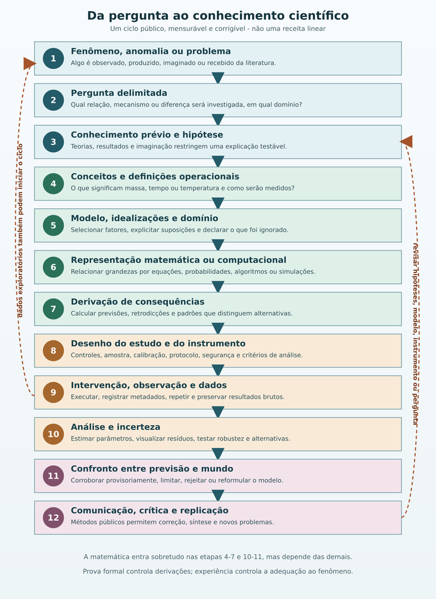

Framework iterativo da investigação científica. Síntese do autor com base em práticas de modelagem, medição, experimento e reprodutibilidade.

### 10.2 Onde entra cada ferramenta

| Ferramenta | Entra principalmente | O que controla |
| --- | --- | --- |
| Linguagem conceitual | Pergunta, definição, hipótese, interpretação | Ambiguidade e significado. |
| Lógica | Hipótese, derivação, análise de argumentos | Se conclusões seguem das razões. |
| Matemática | Modelo, equação, derivação, estatística | Relações precisas e consequências. |
| Programação | Aquisição, simulação, análise, reprodutibilidade | Escala, repetição e rastreabilidade. |
| Instrumento | Operacionalização, intervenção e medição | Contato controlado com o fenômeno. |
| Estatística | Desenho, estimativa, comparação e incerteza | Variabilidade e força inferencial. |
| Filosofia/metodologia | Pressupostos, explicação, objetividade e limites | O que está sendo afirmado e por quê. |
| Comunidade científica | Revisão, replicação, síntese e correção | Robustez além do pesquisador individual. |

### 10.3 A equação não precisa vir antes do laboratório

Há pelo menos quatro rotas legítimas:

1. **Teoria primeiro:** princípios produzem uma equação; depois se busca um teste. A relatividade geral exemplifica parte dessa rota.
2. **Experimento primeiro:** um fenômeno inesperado aparece; a matemática é desenvolvida depois. Descobertas instrumentais frequentemente seguem essa rota.
3. **Co-desenvolvimento:** modelo, dispositivo e dados são ajustados em ciclos. É a situação mais comum em laboratório.
4. **Dados primeiro:** padrões exploratórios sugerem modelos, que precisam de validação independente para evitar sobreajuste.

Portanto, o seu roteiro “imagina - anota - cria equação - vai ao laboratório” descreve um caminho possível, mas não o único. O framework inclui setas de retorno porque um resíduo pode revelar definição inadequada, um instrumento pode criar uma nova pergunta e uma equação pode mostrar que a hipótese era incoerente antes de qualquer teste.

### 10.4 O caderno científico como extensão da mente

Anotar não é copiar o que os olhos veem. É preservar decisões que a memória reconstruiria de modo imperfeito. Cada entrada deve conter:

- data, horário, local e responsáveis;
- pergunta da sessão;
- versão do protocolo e do código;
- materiais, calibração e condições ambientais;
- dados brutos, inclusive resultados “ruins”;
- decisões tomadas e sua justificativa;
- erros, desvios e mudanças;
- fotografia ou esquema do arranjo;
- próximo teste capaz de diferenciar explicações.

O caderno permite separar o que foi previsto antes dos dados do que foi explicado depois. Em projetos computacionais, controle de versão, ambiente, *seeds*, dados imutáveis e scripts de análise cumprem função análoga. 33 75

## 11. Estudo replicável: o plano inclinado de Galileu

### 11.1 Por que este caso foi escolhido

O plano inclinado é uma teoria científica em miniatura. Ele contém fenômeno, conceito, idealização, equação, previsão, instrumento, repetição, incerteza, gráfico, inferência e crítica. Galileu descreveu em *Duas novas ciências* uma prancha inclinada com canal, esfera e relógio de água; afirmou repetir medições e obter que os espaços percorridos estavam entre si como os quadrados dos tempos. 51

O debate historiográfico já questionou se certos experimentos foram físicos ou apenas mentais. Reconstruções mostraram que instrumentos compatíveis com a descrição podiam produzir precisão suficiente. Straulino reconstruiu o arranjo para estudantes de 14 a 18 anos, repetiu 30 medições por distância e analisou $t^2$ em função da distância com incertezas. 52

Este manual propõe uma **replicação didática moderna**, não uma tentativa de reproduzir exatamente todas as condições do século XVII.

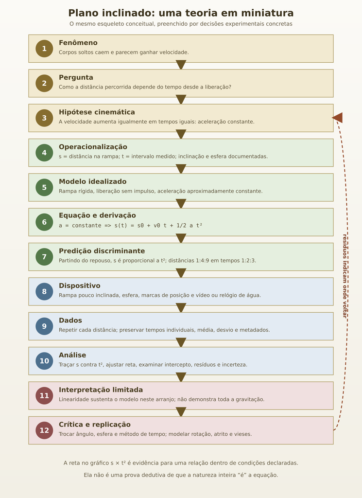

Aplicação do framework geral ao experimento do plano inclinado.

### 11.2 Pergunta e hipóteses rivais

**Pergunta:** para uma esfera liberada do repouso numa rampa fixa, qual relação descreve a distância $s$ em função do tempo $t$?

**Modelo M1 - velocidade constante:**

$$s(t)=\beta_0+\beta_1t.$$

**Modelo M2 - aceleração aproximadamente constante:**

$$s(t)=\beta_0+\beta_1t+\beta_2t^2.$$

Se a esfera parte do repouso no ponto definido como zero, espera-se $\beta_0\approx0$, $\beta_1\approx0$ e $\beta_2>0$. A hipótese relevante não é “o gráfico ficará bonito”, mas que o termo quadrático acrescentará estrutura preditiva e que os resíduos de M2 serão menores e menos sistemáticos que os de M1.

### 11.3 Como a equação é construída

Comece pela definição de aceleração:

$$a=\frac{dv}{dt}.$$

Assuma $a$ constante. Integrar no tempo fornece

$$v(t)=v_0+at.$$

Como $v=ds/dt$, uma segunda integração fornece

$$s(t)=s_0+v_0t+\frac12at^2.$$

Essa é a parte dedutiva. A passagem para a rampa exige hipóteses físicas: a aceleração efetiva deve permanecer aproximadamente constante; a esfera deve rolar de modo regular; o ponto de liberação precisa ser reproduzível; atrito e deformação não podem variar de forma dominante.

Para uma esfera maciça rolando sem deslizar, a aceleração ao longo de uma rampa de ângulo $\theta$ não é simplesmente $g\sin\theta$, porque parte da energia está na rotação. O modelo mais refinado fornece

$$a=\frac{g\sin\theta}{1+I/(mR^2)}
=\frac{5}{7}g\sin\theta,$$

pois $I=\frac25mR^2$ para uma esfera maciça ideal. **O teste básico de $s\propto t^2$ não exige conhecer esse coeficiente**, mas estimar $g$ exige modelar rotação, ângulo e geometria da pista.

### 11.4 Materiais e segurança

- prancha reta ou perfil com 1,5 a 3 m;
- esfera metálica ou bolinha rígida uniforme;
- suporte estável para inclinação pequena;
- trena ou régua longa;
- fita para marcar cinco ou mais distâncias;
- celular fixo, preferencialmente com 60 ou mais quadros por segundo;
- nível ou aplicativo de inclinação;
- anteparo macio no fim da rampa;
- planilha ou programa para análise.

**Segurança:** use rampa baixa e firmemente apoiada; mantenha pés, rosto, crianças e animais fora da trajetória; não improvise suportes sobre móveis instáveis; não use esfera pesada em direção a vidro; filme lateralmente sem segurar o celular durante a descida.

### 11.5 Pré-registro didático

Antes de medir, escreva:

1. hipótese principal: M2 superará M1;
2. distâncias escolhidas;
3. número de repetições - recomenda-se pelo menos 10 por distância;
4. regra de exclusão - por exemplo, liberar com impulso visível;
5. como o início e o fim serão marcados no vídeo;
6. resolução temporal do vídeo;
7. quais gráficos e ajustes serão produzidos;
8. critério de conclusão;
9. limitações antecipadas.

O objetivo não é burocracia. É evitar mudar a regra depois de descobrir qual escolha favorece o resultado.

### 11.6 Procedimento

1. Fixe a rampa e meça seu ângulo ou razão altura/comprimento.
2. Marque posições $s$ a partir do mesmo ponto de liberação.
3. Posicione a câmera perpendicularmente à região observada e inclua uma escala.
4. Grave um teste e verifique iluminação, foco e taxa real de quadros.
5. Desenvolva um mecanismo de liberação sem impulso - uma pequena barreira removida verticalmente.
6. Para cada posição, registre ao menos 10 descidas sem alterar a rampa.
7. Preserve todos os vídeos e atribua identificadores únicos.
8. Extraia o quadro de liberação e o quadro de passagem na marca; calcule $t=\Delta n/f$, onde $\Delta n$ é a diferença de quadros e $f$ a taxa de quadros por segundo.
9. Registre falhas sem apagá-las; aplique a regra de exclusão definida.
10. Repita a sessão em outro dia ou com outro operador.

### 11.7 Estrutura mínima da tabela de dados

| campo | unidade/tipo | função |
| --- | --- | --- |
| `sessao` | texto | identifica dia e configuração |
| `ensaio` | inteiro | preserva repetição individual |
| `distancia_m` | m | variável de posição |
| `quadro_inicio` | quadro | evento operacional de liberação |
| `quadro_fim` | quadro | evento operacional de chegada |
| `fps_real` | quadro/s | base do tempo |
| `tempo_s` | s | $(n_f-n_i)/fps$ |
| `inclinação_graus` | grau | condição do sistema |
| `esfera_id` | texto | material e dimensões |
| `excluido` | sim/não | aplicação transparente da regra |
| `motivo` | texto | justificativa da exclusão |

### 11.8 Análise em seis níveis

**Nível 1 - dados brutos:** veja vídeos e tempos individuais. Não comece apenas pelas médias.

**Nível 2 - distribuição:** para cada distância, calcule média, mediana, desvio-padrão e amplitude. Repetições revelam variabilidade que uma única descida esconderia.

**Nível 3 - transformação prevista:** trace $s$ contra $t^2$. Se $s\approx\frac12at^2$, os pontos devem aproximar uma reta.

**Nível 4 - modelos rivais:** ajuste M1 e M2 aos dados individuais. Compare resíduos e desempenho em dados reservados, não apenas $R^2$.

**Nível 5 - incerteza:** propague a resolução de quadros e a incerteza de posição. O tempo tem discretização aproximada de um quadro em cada evento, além da ambiguidade do observador.

**Nível 6 - robustez:** repita com outra inclinação, outro operador e outra esfera. Um modelo é mais convincente quando o padrão sobrevive a mudanças que não deveriam destruí-lo.

### 11.9 Como interpretar sem exagerar

Se $s$ contra $t^2$ for aproximadamente linear e M2 superar M1, conclua:

> Nas condições do arranjo, as medições são compatíveis com movimento de aceleração aproximadamente constante, e o modelo quadrático representa melhor a relação distância-tempo do que o modelo de velocidade constante.

Não conclua:

- “provei que a gravidade é verdadeira”;
- “provei toda a mecânica de Newton”;
- “qualquer corpo em qualquer condição obedece exatamente à equação”;
- “o valor de $g$ é o coeficiente bruto da rampa”.

Fricção, rotação, inclinação, deformação, perspectiva, taxa de quadros e definição dos eventos limitam a inferência. A virtude científica está em declarar precisamente o que o resultado sustenta.

### 11.10 Como transformar a replicação em pesquisa própria

Depois da replicação básica, formule uma única extensão:

- a aceleração estimada varia com $\sin\theta$?
- esfera maciça e oca produzem coeficientes diferentes?
- um trilho em V altera o momento de inércia efetivo?
- cronômetro manual e vídeo produzem vieses diferentes?
- qual comprimento mínimo permite distinguir M1 de M2?
- qual efeito ocorre ao introduzir uma região rugosa?

Agora o trabalho deixa de apenas repetir um resultado e passa a investigar uma pergunta nova. Use desenho experimental, análise de erros e regressão para sustentar a extensão. 66 67 68 70

## 12. Como uma conta ajuda uma teoria

### 12.1 Sete funções diferentes da matemática

Uma conta pode ajudar uma teoria ao:

1. **torná-la precisa:** substituir “cai cada vez mais rápido” por relação quantitativa;
2. **verificar coerência interna:** descobrir contradições ou equações incompatíveis;
3. **derivar consequências ocultas:** obter previsões não visíveis na ideia verbal;
4. **unificar fenômenos:** mostrar que queda e órbita obedecem à mesma estrutura;
5. **estimar parâmetros:** inferir $g$, condutividade ou curvatura a partir de dados;
6. **comparar alternativas:** quantificar qual modelo prevê melhor;
7. **definir novos observáveis:** indicar o que instrumentos devem procurar.

Uma teoria verbal pode parecer plausível e ainda ser matematicamente impossível. Outra pode ser consistente, mas prever um efeito já contradito. A conta age como disciplina: força a hipótese a “pagar suas dívidas” em consequências.

### 12.2 Três auditorias que uma equação deve enfrentar

**Auditoria formal:** os passos estão corretos? As unidades combinam? Há solução? A equação conserva o que deveria conservar?

**Auditoria física:** recupera casos conhecidos? Respeita simetrias? Os parâmetros possuem interpretação? A idealização é coerente?

**Auditoria empírica:** suas previsões concordam com medições novas? Modelos rivais também concordam? Quais erros sistemáticos poderiam imitar o efeito?

Passar pela primeira não implica passar pelas outras duas.

### 12.3 Um cálculo não precisa usar os dados do teste

Na ciência teórica, o pesquisador pode calcular antes do experimento. A partir de uma estrutura matemática e de parâmetros já conhecidos, ele deriva uma consequência. O experimento posterior procura essa assinatura. Esse distanciamento entre construção e teste fortalece a inferência porque reduz a liberdade de adaptar a teoria ao resultado.

O inverso também ocorre: dados conhecidos podem orientar a teoria. Nesse caso, testes independentes são especialmente importantes. O avanço anômalo do periélio de Mercúrio já era conhecido quando Einstein obteve o valor correto na relatividade geral; a concordância foi uma retrodicção importante, mas o desvio da luz e testes posteriores ampliaram o corpo de evidências. 59 60 61

## 13. Einstein em *Genius*: o que a dramatização simplifica

### 13.1 Quem provavelmente era o matemático

Se a cena ocorre durante a formação da relatividade geral em Zurique, o personagem mais provável é **Marcel Grossmann**, colega de Einstein e especialista em geometria. Grossmann ajudou Einstein a encontrar e usar cálculo tensorial e geometria diferencial; ambos publicaram em 1913 a teoria preliminar *Entwurf*. Se a cena retrata a disputa final de 1915, **David Hilbert** também pode aparecer como interlocutor e competidor. A série dramatiza relações e comprime cronologias; não se deve tratar o diálogo como fonte histórica primária. 58 60

### 13.2 Einstein não viu o espaço-tempo curvo com os olhos

Uma reconstrução melhor contém:

1. **relatividade especial (1905):** espaço e tempo dependem do estado de movimento, e a velocidade da luz possui papel invariável; 57
2. **insatisfação:** a gravitação newtoniana atua instantaneamente e não se encaixa naturalmente na estrutura relativística;
3. **princípio de equivalência (1907):** localmente, queda livre e ausência de gravidade possuem relação profunda;
4. **experimentos mentais:** elevadores, relógios, raios de luz e observadores acelerados exploram consequências conceituais;
5. **problema matemático:** descrever geometria variável e leis independentes de coordenadas arbitrárias;
6. **ferramenta:** métricas, tensores, curvatura e cálculo diferencial absoluto;
7. **iterações:** teoria de 1913, dificuldades e revisão;
8. **equações de campo de 1915:** relação entre geometria e conteúdo de energia-momento. 58 59 60

Einstein combinou princípios físicos, conhecimento experimental, matemática, analogias e tentativas malsucedidas. A equação final não foi uma tradução direta de uma imagem mental única.

### 13.3 O que a equação de campo diz

Em notação moderna compacta:

$$G_{\mu\nu}+\Lambda g_{\mu\nu}=\frac{8\pi G}{c^4}T_{\mu\nu}.$$

- $g_{\mu\nu}$ descreve a métrica do espaço-tempo;
- $G_{\mu\nu}$ resume aspectos de sua curvatura;
- $T_{\mu\nu}$ representa densidade e fluxo de energia e momento;
- $G$ e $c$ conectam escalas físicas;
- $\Lambda$ é a constante cosmológica.

A frase popular “matéria diz ao espaço-tempo como curvar e espaço-tempo diz à matéria como mover” é um auxílio, não a teoria completa. É necessário resolver equações com condições apropriadas e usar a equação geodésica ou dinâmica da matéria.

### 13.4 O que o matemático ajudou a fazer

Grossmann não simplesmente “fez as contas que Einstein não sabia”. A colaboração ajudou a:

- identificar uma linguagem matemática apta a representar curvatura;
- expressar leis em formas que não dependessem de coordenadas particulares;
- investigar tensores candidatos às equações gravitacionais;
- verificar propriedades de conservação e consistência;
- conectar intuição física e estrutura geométrica.

Matemática aqui não é ornamento. Sem ela, “gravidade é geometria” permanece metáfora. Com ela, torna-se um sistema capaz de gerar soluções, limites e previsões.

### 13.5 O cálculo “provou” a teoria?

Não no sentido empírico. Os cálculos podiam mostrar condicionalmente que:

- certas equações satisfaziam requisitos formais;
- a teoria recuperava aproximadamente a gravitação de Newton em campo fraco;
- uma solução implicava determinado avanço do periélio;
- a luz deveria desviar certa quantidade nas proximidades do Sol.

Depois, dados avaliaram essas consequências. A observação do eclipse de 1919 tornou-se famosa, mas não foi uma prova lógica final e sua análise histórica é mais complexa que a narrativa heroica. Testes posteriores incluíram desvio gravitacional de frequência, atraso de radar, pulsares binários, lentes, relógios, sistemas de navegação e ondas gravitacionais. A primeira detecção direta de ondas gravitacionais pelo LIGO, observada em 2015 e publicada em 2016, confirmou uma previsão importante em regime dinâmico forte. 61 62

### 13.6 A versão corrigida do seu entendimento

Sua reconstrução inicial era:

> Einstein observa - abstrai - codifica em equação - a equação é provada - experimento observa - teoria vira verdade.

A versão epistemicamente mais precisa é:

> Einstein parte de teorias, evidências, incompatibilidades e experimentos mentais; formula princípios; procura uma estrutura matemática; testa coerência e limites; deriva consequências; confronta algumas com dados conhecidos e outras com observações independentes; a comunidade repete e amplia testes; a teoria permanece extraordinariamente corroborada em seu domínio, sem se tornar uma verdade dedutivamente provada sobre toda realidade.

## 14. Quando uma teoria merece confiança

### 14.1 Um resultado favorável não encerra o problema

Se uma previsão coincide com um dado, ao menos quatro situações são possíveis:

1. a teoria capturou uma estrutura real relevante;
2. outra teoria também produziria a mesma previsão;
3. parâmetros foram ajustados com liberdade suficiente para garantir a concordância;
4. erro ou viés criou uma coincidência.

Por isso, cientistas valorizam previsões novas, testes arriscados, medições independentes, variedade de fenômenos, replicação e integração com outros conhecimentos. Consenso científico se forma sobre um corpo de evidências, não sobre um experimento isolado. 33

O *Reference Manual on Scientific Evidence* de 2025 formula a mesma cautela em contexto jurídico: hipóteses, teorias e leis são avaliadas por corpos de evidência, e nenhuma investigação isolada encerra por si só uma questão científica complexa. 69

### 14.2 Critérios de força de uma teoria

Uma teoria ganha confiança quando apresenta combinação de:

- **coerência interna:** não contém contradições relevantes;
- **precisão:** produz consequências suficientemente determinadas;
- **adequação empírica:** corresponde a dados de boa qualidade;
- **alcance:** trata múltiplas classes de fenômenos;
- **unificação:** conecta regularidades antes separadas;
- **fecundidade:** gera novas perguntas e descobertas;
- **robustez:** sobrevive a métodos e instrumentos diferentes;
- **simplicidade disciplinada:** evita complexidade ad hoc sem sacrificar fenômenos;
- **compatibilidade ou integração:** relaciona-se a conhecimento bem sustentado;
- **transparência de domínio:** declara onde e por que deve falhar.

Nenhum critério sozinho decide. Uma teoria mais simples pode prever pior; uma teoria nova pode entrar em tensão legítima com conhecimento anterior; duas teorias podem ser empiricamente equivalentes num domínio.

### 14.3 Confirmação, falsificação e revisão

Popper ensinou a procurar riscos de refutação, não apenas exemplos favoráveis. Kuhn mostrou que teorias operam dentro de tradições de problemas, instrumentos e padrões; anomalias podem ser toleradas e investigadas antes de uma mudança de quadro. Filosofia posterior examinou confirmação probabilística, modelos, experimentação e pluralidade metodológica. 28 30 31

Na prática, use três perguntas:

1. **O que exatamente seria incompatível com esta versão da hipótese?**
2. **Quais hipóteses auxiliares foram necessárias para gerar a previsão?**
3. **Qual teste diferencia a explicação principal de seus melhores rivais?**

### 14.4 Incerteza não é ignorância total

Uma medida $1{,}23\pm0{,}03$ não confessa fracasso; ela informa resolução e dispersão segundo um modelo. Distinga:

- **erro aleatório:** variação entre repetições;
- **erro sistemático:** deslocamento persistente produzido pelo procedimento;
- **incerteza de medição:** caracterização do intervalo de valores plausíveis sob conhecimento disponível;
- **erro de modelo:** discrepância causada por idealizações;
- **incerteza de parâmetro:** conhecimento incompleto sobre coeficientes;
- **incerteza estrutural:** dúvida sobre a própria forma do modelo.

Repetir muitas vezes reduz a incerteza da média associada a flutuações independentes, mas não corrige automaticamente uma régua mal calibrada. Análise de erros, desenho experimental e regressão devem acompanhar a matemática substantiva. 66 67 68

## 15. Da relatividade à inteligência artificial: o estado em 2026

### 15.1 Computação adicionou uma nova camada

No século XX, Turing formalizou a ideia de procedimento computável e demonstrou limites do cálculo automático. Gödel já havia mostrado limites de sistemas formais suficientemente expressivos. Computadores não apagaram lógica, prova ou experimento; tornaram possíveis simulações, análise massiva, aquisição automática e verificação formal. 79 80

Uma simulação introduz uma cadeia adicional:

$$\text{modelo} \rightarrow \text{discretização} \rightarrow \text{algoritmo}
\rightarrow \text{código} \rightarrow \text{hardware} \rightarrow \text{resultado}.$$

Cada seta pode introduzir erro. Mesmo com teoria correta, malha grosseira, instabilidade numérica ou defeito de implementação podem produzir resposta errada. Verificação pergunta “resolvemos corretamente as equações?”; validação pergunta “escolhemos equações adequadas ao sistema real?”.

### 15.2 Provas assistidas por computador

Assistentes como Lean representam definições, teoremas e provas numa linguagem formal cujo núcleo verifica cada passo. Uma prova aceita por esse núcleo oferece garantia condicional muito forte: dadas as definições, axiomas, biblioteca e implementação confiável, o termo de prova satisfaz as regras. 71 72

Isso não transforma um modelo físico formalizado em verdade empírica. Um computador pode verificar impecavelmente um teorema sobre um sistema que não representa a natureza.

### 15.3 IA matemática até 2026

Sistemas neuro-simbólicos e de aprendizagem por reforço passaram a propor construções e buscar provas verificáveis. O AlphaProof combinou aprendizagem por reforço com o ambiente formal Lean e atingiu desempenho de nível olímpico em problemas selecionados; o artigo metodológico foi publicado on-line em 2025 e integra volume da *Nature* de 2026. 73

Em maio de 2026, a OpenAI relatou que um modelo geral encontrou uma nova construção que refutava uma conjectura central associada ao problema de distâncias unitárias no plano, acompanhada de prova e avaliação humana. O caso é um marco, mas também ensina prudência: uma demonstração deve ser verificada, contextualizada, comparada à literatura e separada das declarações promocionais. 74

### 15.4 IA científica não remove a ponte com o mundo

Uma IA pode:

- sugerir hipóteses;
- buscar literatura;
- encontrar padrões;
- propor equações;
- planejar experimentos;
- controlar instrumentos;
- gerar código;
- analisar dados;
- procurar provas formais.

Mas continuam necessárias:

- proveniência de dados;
- detecção de contaminação e sobreajuste;
- calibração instrumental;
- distinção entre correlação e mecanismo;
- controle de versões e ambientes;
- validação externa;
- responsabilidade humana;
- avaliação ética e social.

Uma frase produzida por IA não é evidência; uma equação gerada não é teoria aceita; uma prova informal plausível não é prova verificada; e uma prova formal de uma afirmação matemática não é teste físico. A IA acrescenta agentes ao ciclo, não elimina o ciclo.

## 16. Como enxergar matemática e ciência na vida cotidiana

### 16.1 O exercício das cinco traduções

Escolha um fenômeno simples - resfriamento do café, sombra de um poste, bateria do celular, som de uma corda ou queda de uma bola - e escreva cinco descrições:

1. **cotidiana:** “o café esfria rápido no começo”;
2. **conceitual:** a taxa de mudança parece depender da diferença para o ambiente;
3. **operacional:** medir temperatura e ambiente a intervalos definidos;
4. **matemática:** $dT/dt=-k(T-T_{amb})$;
5. **inferencial:** ajustar $k$, examinar resíduos e testar outro recipiente.

Você verá a ponte sendo construída. A equação não substitui a frase; torna algumas relações mais exatas e cobra definições.

### 16.2 Um programa de seis experimentos

| Experimento | Conceito central | Matemática | Erro a procurar |
| --- | --- | --- | --- |
| Sombra ao meio-dia | Geometria e correspondência | Triângulos, ângulos, razão | Poste inclinado, horário, refração. |
| Queda filmada | Movimento acelerado | Função quadrática | Perspectiva, ar, taxa de quadros. |
| Plano inclinado | Modelo, repetição e resíduos | $s\propto t^2$ | Liberação, rotação, atrito. |
| Pêndulo pequeno | Aproximação e escala | $T\approx2\pi\sqrt{L/g}$ | Amplitude, comprimento efetivo. |
| Resfriamento | Equação diferencial | Exponencial | Ambiente variável, convecção. |
| Intensidade luminosa | Lei de potência | $I\propto1/r^2$ | Luz ambiente, sensor saturado. |

Em todos, siga a mesma disciplina: segurança, pergunta, hipótese, variáveis, protocolo, dados brutos, incerteza, comparação, limitações e replicação.

### 16.3 O teste do contraexemplo cotidiano

Quando ouvir uma generalização - “objetos mais pesados sempre caem mais rápido”, “dobrar X dobra Y”, “este remédio funciona comigo” -, pergunte:

- quais condições estão ocultas?
- qual é a unidade de análise?
- o que está sendo comparado?
- existe variável de confusão?
- um único contraexemplo refuta uma afirmação universal?
- o resultado sobreviveria a medição cega e repetida?

Esse hábito une lógica, matemática e método antes de qualquer laboratório sofisticado.

## 17. Modelo mental para ensinar e pesquisar

### 17.1 A frase de doze partes

Para explicar uma pesquisa a outra pessoa, complete:

> “Diante de **[fenômeno]**, perguntamos **[questão]**. Com base em **[conhecimento]**, propusemos **[hipótese]**. Definimos **[grandezas]** por **[procedimentos]** e representamos o sistema como **[modelo]**, assumindo **[idealizações]**. Disso derivamos **[previsão]**. Construímos **[desenho/instrumento]**, coletamos **[dados]**, analisamos por **[método]** com **[incertezas]** e concluímos **[alcance limitado]**. A próxima crítica é **[teste rival/replicação]**.”

Se uma lacuna não pode ser preenchida, você encontrou uma fragilidade metodológica.

### 17.2 O cubo da confiança

Pense em três eixos independentes:

1. **validade formal:** a derivação está correta?
2. **validade de medição:** os dados representam a grandeza?
3. **validade externa:** a conclusão se aplica além do arranjo?

Um estudo pode ser alto em um eixo e baixo em outro. Um cálculo perfeito com sensor inadequado falha na medição. Um experimento preciso em uma amostra estreita pode falhar externamente. A força global não é igual ao melhor eixo.

### 17.3 A escada de afirmações

Ordene afirmações do menos ao mais exigente:

1. **observamos** um padrão nos dados;
2. **o modelo descreveu** o padrão neste conjunto;
3. **o modelo previu** novos dados no mesmo domínio;
4. **a intervenção alterou** o resultado como previsto;
5. **alternativas relevantes foram desfavorecidas**;
6. **o resultado foi replicado** por métodos independentes;
7. **a teoria integrou** fenômenos heterogêneos;
8. **o mecanismo permanece confiável** em domínios ampliados.

Não suba mais degraus do que a evidência permite.

### 17.4 Checklist antes de chamar algo de “explicação científica”

- O fenômeno e o domínio estão definidos?
- Os conceitos possuem operações de medida?
- A hipótese exclui resultados possíveis?
- As idealizações foram declaradas?
- A equação foi derivada, ajustada ou apenas escolhida?
- As unidades e casos-limite fazem sentido?
- Há uma previsão que não foi usada para construir o modelo?
- O instrumento foi calibrado?
- Dados brutos e exclusões foram preservados?
- Incertezas aleatórias e sistemáticas foram distinguidas?
- Modelos rivais foram comparados?
- A conclusão é proporcional à evidência?
- Outra pessoa poderia repetir o procedimento?

## 18. Glossário final: distinções que devem permanecer separadas

| Termo | Definição compacta | Pergunta de controle |
| --- | --- | --- |
| Abdução | Inferência para a melhor explicação disponível. | Quais rivais foram considerados? |
| Algoritmo | Procedimento finito e especificado para uma tarefa. | Termina e produz o resultado pretendido? |
| Argumento | Premissas oferecidas em apoio a uma conclusão. | As razões sustentam a conclusão? |
| Axioma | Ponto de partida de um sistema formal. | Em qual sistema foi adotado? |
| Causalidade | Relação em que alterações de um fator contribuem para alterações de outro. | Houve intervenção ou controle de confundidores? |
| Conceito | Unidade de significado para classificar ou relacionar. | Está definido no contexto? |
| Conclusão | Afirmação sustentada por um argumento ou análise. | Seu alcance excede os dados? |
| Conjectura | Proposição matemática ainda sem prova ou refutação. | Há demonstração ou contraexemplo? |
| Corolário | Consequência relativamente imediata de teorema. | De qual resultado decorre? |
| Dado | Registro produzido por procedimento. | Como foi gerado e preservado? |
| Dedução | Inferência que preserva verdade dada a validade e premissas verdadeiras. | A forma é válida? |
| Definição | Regra de uso de termo. | É lexical, operacional ou matemática? |
| Domínio | Condições e sistemas em que um modelo pretende valer. | Onde se espera falha? |
| Equação | Igualdade afirmada entre expressões. | É identidade, problema ou lei/modelo? |
| Evidência | Informação relevante para comparar afirmações. | Em relação a qual hipótese? |
| Experimento | Intervenção organizada para produzir conhecimento. | O que foi manipulado e controlado? |
| Explicação | Estrutura que mostra por que ou como um fenômeno ocorre. | Vai além de ajustar uma curva? |
| Função | Regra que associa entradas admissíveis a saídas. | Qual é o domínio e o contradomínio? |
| Hipótese | Proposição provisória com consequências testáveis. | O que poderia contrariá-la? |
| Idealização | Simplificação deliberada do sistema. | O fator omitido é desprezível para a pergunta? |
| Indução | Generalização a partir de casos. | A amostra sustenta o alcance? |
| Inferência | Passagem de razões ou dados a uma conclusão. | Qual regra ou modelo autoriza a passagem? |
| Lei científica | Regularidade ou relação geral sob condições. | Qual é o domínio e a precisão? |
| Lema | Teorema auxiliar. | Qual prova principal ele sustenta? |
| Medição | Atribuição de valor mediante operação, padrão e modelo. | Qual é a incerteza? |
| Modelo | Representação seletiva de sistema-alvo. | O que preserva e o que omite? |
| Objetividade | Robustez a perspectivas ou vieses relevantes. | Que controles públicos a sustentam? |
| Observação | Registro obtido sem ou com intervenção limitada. | Qual instrumento e teoria a tornam possível? |
| Parâmetro | Quantidade que caracteriza família de modelos. | Foi fixado ou estimado? |
| Premissa | Afirmação usada como ponto de partida. | É assumida, definida ou empiricamente sustentada? |
| Predição | Consequência observável obtida antes de seu teste relevante. | Foi especificada antes dos dados? |
| Proposição | Enunciado com valor de verdade. | Está suficientemente determinado? |
| Prova | Demonstração formal de consequência. | Quais axiomas e regras utiliza? |
| Replicação | Novo estudo destinado a verificar a robustez de um resultado. | O que foi mantido e o que mudou? |
| Resíduo | Diferença entre dado observado e previsão do modelo. | Apresenta padrão sistemático? |
| Simulação | Execução computacional de um modelo. | Foi verificada e validada? |
| Teorema | Proposição demonstrada em um sistema. | Onde está a prova? |
| Teoria científica | Estrutura explicativa de conceitos, modelos e evidências. | Que fenômenos integra e que testes enfrenta? |
| Validade lógica | Impossibilidade de premissas verdadeiras e conclusão falsa. | Depende da forma, não da verdade factual. |
| Variável | Símbolo ou característica que pode assumir valores. | Como foi definida e medida? |

## 19. Respostas diretas às perguntas iniciais

### A matemática surgiu com o *Homo sapiens* das cavernas?

Capacidades quantitativas são mais antigas e não exclusivas do *Homo sapiens*. Sistemas exatos de números, registros e procedimentos foram construídos culturalmente durante longos períodos. Não conhecemos o primeiro indivíduo.

### Ela foi inventada ou descoberta?

Símbolos e sistemas são inventados; consequências internas frequentemente são descobertas; a aplicação de uma estrutura ao mundo é testada. A metafísica completa permanece debatida.

### Quem inventou a equação?

Ninguém sozinho. Problemas equivalentes a equações aparecem em tradições mesopotâmicas; Diophantus usou abreviações; al-Khwārizmī sistematizou álgebra retórica; notação simbólica amadureceu na Europa moderna; Recorde introduziu “=” em 1557. Newton nasceu numa tradição algébrica já antiga.

### Por que uma equação explica?

Porque símbolos são ligados a grandezas por regras de medição, a equação preserva relações relevantes, deriva consequências e essas consequências sobrevivem a testes. A equação isolada não explica.

### Qual foi o primeiro humano a combinar matemática e experimento?

Não há critério único. Eratóstenes combina observação e geometria; Arquimedes, matemática e física; Ibn al-Haytham, óptica matemática e experimentos; Galileu, leis do movimento e mensuração quantitativa deliberada. Para o formato mais próximo do laboratório de física moderno, Galileu é o candidato pedagógico mais forte, não um inventor absoluto.

### Os monges de Merton trocaram lógica por matemática?

Não. Usaram lógica escolástica, matemática e filosofia natural conjuntamente para quantificar problemas idealizados. Sua prática não era principalmente experimental. Galileu conectou relações cinemáticas a hipóteses físicas e medições de outra maneira.

### A matemática provou a teoria de Einstein?

Ela tornou a teoria formulável, verificou consequências condicionais, recuperou limites e gerou previsões. Observações e experimentos forneceram evidência empírica. Nenhum cálculo isolado provou que a relatividade geral é a verdade final da natureza.

### Se há prova matemática, há certeza sobre a realidade?

Há certeza condicional sobre a derivação, não sobre a adequação do modelo ao mundo. A ponte empírica permanece falível e testável.

## 20. Conclusão: o conhecimento como ponte corrigível

A história não começa com uma equação e não termina com uma “prova” experimental. Começa com organismos capazes de distinguir, lembrar e agir; passa por linguagem, sinais, número, escrita, argumento, demonstração e medida; ganha novas formas com álgebra, instrumentos, cálculo, estatística e computação; e chega a 2026 com humanos e máquinas propondo e verificando estruturas formais.

O fio unificador é a construção de **representações corrigíveis**. A lógica controla inferências. A matemática comprime relações e revela consequências. O experimento cria situações em que o mundo pode contrariar expectativas. A medição transforma interações em dados sob incerteza. A estatística disciplina comparações. A comunidade amplia a objetividade por crítica e replicação.

Você não precisa esperar dominar toda a matemática para começar. Escolha um fenômeno seguro, formule uma pergunta pequena, escreva duas hipóteses rivais, defina grandezas, construa um protocolo, preserve dados brutos e procure onde seu modelo falha. O nascimento da atitude científica, em cada pesquisador, ocorre quando o desejo de estar certo é substituído pelo desejo de construir um teste que possa revelar o erro.

## Referências

[1] HAUSER, Marc D. et al. The Mystery of Language Evolution. *Frontiers in Psychology*, v. 5, 2014. [DOI](https://doi.org/10.3389/fpsyg.2014.00401). ↩︎

[2] D’ERRICO, Francesco et al. From Number Sense to Number Symbols: An Archaeological Perspective. *Philosophical Transactions of the Royal Society B*, v. 373, 1740, 2018. [DOI](https://doi.org/10.1098/rstb.2016.0518). ↩︎

[3] SCHLAUDT, Oliver. Type and Token in the Prehistoric Origins of Numbers. *Cambridge Archaeological Journal*, v. 30, n. 4, p. 629-646, 2020. [DOI](https://doi.org/10.1017/S0959774320000175). ↩︎

[4] SCHMANDT-BESSERAT, Denise. *Before Writing. Volume I: From Counting to Cuneiform*. Austin: University of Texas Press, 1992. [Autora e síntese](https://sites.utexas.edu/dsb/tokens/from-accounting-to-writing/). ↩︎

[5] ROBSON, Eleanor. *Mathematics in Ancient Iraq: A Social History*. Princeton: Princeton University Press, 2008. [Editora](https://press.princeton.edu/books/hardcover/9780691091822/mathematics-in-ancient-iraq). ↩︎

[6] KATZ, Victor J. *A History of Mathematics: An Introduction*. 3. ed. Boston: Addison-Wesley, 2009. [WorldCat](https://search.worldcat.org/title/244060368). ↩︎

[7] HØYRUP, Jens. *Lengths, Widths, Surfaces: A Portrait of Old Babylonian Algebra and Its Kin*. New York: Springer, 2002. [DOI](https://doi.org/10.1007/978-1-4757-3685-4). ↩︎

[8] CHACE, Arnold Buffum et al. *The Rhind Mathematical Papyrus*. Oberlin: Mathematical Association of America, 1927-1929. [Internet Archive](https://archive.org/details/rhindmathematica0000unse). ↩︎

[9] BRITISH MUSEUM. Learn Maths from Egyptian Secrets in the Rhind Mathematical Papyrus. London, 2025. [Museu](https://www.britishmuseum.org/blog/learn-maths-egyptian-secrets-rhind-mathematical-papyrus). ↩︎

[10] NETZ, Reviel. *The Shaping of Deduction in Greek Mathematics*. Cambridge: Cambridge University Press, 1999. [DOI](https://doi.org/10.1017/CBO9780511543296). ↩︎

[11] ARISTOTLE. *Posterior Analytics*. Trad. Jonathan Barnes. 2. ed. Oxford: Clarendon Press, 1994. [WorldCat](https://search.worldcat.org/title/28676917). ↩︎

[12] EUCLID. *The Thirteen Books of the Elements*. Trad. Thomas L. Heath. 2. ed. Cambridge: Cambridge University Press, 1926. [Texto digital](https://mathcs.clarku.edu/~djoyce/java/elements/elements.html). ↩︎

[13] GENSLER, Harry J. *Introduction to Logic*. 3. ed. New York: Routledge, 2017. [Editora](https://www.routledge.com/Introduction-to-Logic/Gensler/p/book/9781138910577). ↩︎

[14] HAMMACK, Richard. *Book of Proof*. 3. ed. Richmond: Virginia Commonwealth University, 2018. [Texto aberto](https://www.people.vcu.edu/~rhammack/BookOfProof/). ↩︎

[15] VELLEMAN, Daniel J. *How to Prove It: A Structured Approach*. 3. ed. Cambridge: Cambridge University Press, 2019. [DOI](https://doi.org/10.1017/9781108539890). ↩︎

[16] LAKATOS, Imre. *Proofs and Refutations: The Logic of Mathematical Discovery*. Cambridge: Cambridge University Press, 1976. [DOI](https://doi.org/10.1017/CBO9781139171472). ↩︎

[17] HORSTEN, Leon. Philosophy of Mathematics. In: *Stanford Encyclopedia of Philosophy*. Stanford: Metaphysics Research Lab, revisão contínua. [Verbete](https://plato.stanford.edu/entries/philosophy-mathematics/). ↩︎

[18] BALAGUER, Mark. Platonism in Metaphysics. In: *Stanford Encyclopedia of Philosophy*. Stanford: Metaphysics Research Lab, revisão contínua. [Verbete](https://plato.stanford.edu/entries/platonism/). ↩︎

[19] BUENO, Otávio. Nominalism in the Philosophy of Mathematics. In: *Stanford Encyclopedia of Philosophy*. Stanford: Metaphysics Research Lab, revisão contínua. [Verbete](https://plato.stanford.edu/entries/nominalism-mathematics/). ↩︎

[20] SHAPIRO, Stewart. *Philosophy of Mathematics: Structure and Ontology*. New York: Oxford University Press, 1997. [Editora](https://global.oup.com/academic/product/philosophy-of-mathematics-9780195139303). ↩︎

[21] WIGNER, Eugene P. The Unreasonable Effectiveness of Mathematics in the Natural Sciences. *Communications on Pure and Applied Mathematics*, v. 13, n. 1, p. 1-14, 1960. [DOI](https://doi.org/10.1002/cpa.3160130102). ↩︎

[22] HAMMING, Richard W. The Unreasonable Effectiveness of Mathematics. *American Mathematical Monthly*, v. 87, n. 2, p. 81-90, 1980. [JSTOR](https://www.jstor.org/stable/2321982). ↩︎

[23] FRIGG, Roman; HARTMANN, Stephan. Models in Science. In: *Stanford Encyclopedia of Philosophy*. Stanford: Metaphysics Research Lab, revisão contínua. [Verbete](https://plato.stanford.edu/entries/models-science/). ↩︎

[24] REISS, Julian; SPRENGER, Jan. Scientific Objectivity. In: *Stanford Encyclopedia of Philosophy*. Stanford: Metaphysics Research Lab, 2020. [Verbete](https://plato.stanford.edu/entries/scientific-objectivity/). ↩︎

[25] BOYD, Nora Mills; BOGEN, James. Theory and Observation in Science. In: *Stanford Encyclopedia of Philosophy*. Stanford: Metaphysics Research Lab, revisão contínua. [Verbete](https://plato.stanford.edu/entries/science-theory-observation/). ↩︎

[26] TAL, Eran. Measurement in Science. In: *Stanford Encyclopedia of Philosophy*. Stanford: Metaphysics Research Lab, revisão contínua. [Verbete](https://plato.stanford.edu/entries/measurement-science/). ↩︎

[27] WINTHER, Rasmus Grønfeldt. The Structure of Scientific Theories. In: *Stanford Encyclopedia of Philosophy*. Stanford: Metaphysics Research Lab, revisão contínua. [Verbete](https://plato.stanford.edu/entries/structure-scientific-theories/). ↩︎

[28] GODFREY-SMITH, Peter. *Theory and Reality: An Introduction to the Philosophy of Science*. 2. ed. Chicago: University of Chicago Press, 2021. [Editora](https://press.uchicago.edu/ucp/books/book/chicago/T/bo37447570.html). ↩︎

[29] CHALMERS, Alan F. *What Is This Thing Called Science?* 4. ed. Indianapolis: Hackett, 2013. [Editora](https://hackettpublishing.com/what-is-this-thing-called-science-fourth-edition). ↩︎

[30] POPPER, Karl. *The Logic of Scientific Discovery*. London: Hutchinson, 1959 [original alemão de 1934]. [Editora](https://www.routledge.com/The-Logic-of-Scientific-Discovery/Popper/p/book/9780415278447). ↩︎

[31] KUHN, Thomas S. *The Structure of Scientific Revolutions*. 4. ed. Chicago: University of Chicago Press, 2012 [original de 1962]. [Editora](https://press.uchicago.edu/ucp/books/book/chicago/S/bo13179781.html). ↩︎

[32] NATIONAL ACADEMY OF SCIENCES; INSTITUTE OF MEDICINE. *Science, Evolution, and Creationism*. Washington, DC: National Academies Press, 2008. [DOI e texto aberto](https://doi.org/10.17226/11876). ↩︎

[33] NATIONAL ACADEMIES OF SCIENCES, ENGINEERING, AND MEDICINE. *Reproducibility and Replicability in Science*. Washington, DC: National Academies Press, 2019. [DOI e texto aberto](https://doi.org/10.17226/25303). ↩︎

[34] NATIONAL RESEARCH COUNCIL. *Taking Science to School: Learning and Teaching Science in Grades K-8*. Washington, DC: National Academies Press, 2007. [DOI e texto aberto](https://doi.org/10.17226/11625). ↩︎

[35] FRANKLIN, Allan; PEROVIC, Slobodan. Experiment in Physics. In: *Stanford Encyclopedia of Philosophy*. Stanford: Metaphysics Research Lab, 2023. [Verbete](https://plato.stanford.edu/entries/physics-experiment/). ↩︎

[36] AL-KHWĀRIZMĪ, Muḥammad ibn Mūsā. *The Algebra of Mohammed ben Musa*. Trad. Frederic Rosen. London: Oriental Translation Fund, 1831. [Internet Archive](https://archive.org/details/algebraofmohamme00khuwrich). ↩︎

[37] KATZ, Victor J.; PARSHALL, Karen Hunger. Diophantus. In: *Oxford Classical Dictionary*. Oxford: Oxford University Press, revisão contínua. [Verbete](https://doi.org/10.1093/acrefore/9780199381135.013.2229). ↩︎

[38] CAJORI, Florian. *A History of Mathematical Notations*. 2 v. Chicago: Open Court, 1928-1929. [Internet Archive](https://archive.org/details/b29980343_0001). ↩︎

[39] RECORDE, Robert. *The Whetstone of Witte*. London: John Kyngstone, 1557. [Descrição histórica - Caltech](https://www.caltech.edu/about/news/question-week-who-invented-equal-sign-and-why-171). ↩︎

[40] HUFFMAN, Carl. Archytas. In: *Stanford Encyclopedia of Philosophy*. Stanford: Metaphysics Research Lab. [Verbete arquivado](https://plato.stanford.edu/archives/win2016/entries/archytas/). ↩︎

[41] MATTHEW, Christopher Anthony. *Eratosthenes and the Measurement of the Earth’s Circumference (c. 230 BC)*. Oxford: Oxford University Press, 2023. [Editora](https://global.oup.com/academic/product/eratosthenes-and-the-measurement-of-the-earths-circumference-c230-bc-9780198874317). ↩︎

[42] ARCHIMEDES. *The Works of Archimedes*. Ed. e trad. T. L. Heath. Cambridge: Cambridge University Press, 1897. [Internet Archive](https://archive.org/details/worksofarchimede029517mbp). ↩︎

[43] PTOLEMY. *Ptolemy’s Almagest*. Trad. G. J. Toomer. Princeton: Princeton University Press, 1998. [Editora](https://press.princeton.edu/books/paperback/9780691002606/ptolemys-almagest). ↩︎

[44] SALIBA, George. *Islamic Science and the Making of the European Renaissance*. Cambridge, MA: MIT Press, 2007. [Editora](https://mitpress.mit.edu/9780262516150/islamic-science-and-the-making-of-the-european-renaissance/). ↩︎

[45] IBN AL-HAYTHAM. *The Optics of Ibn al-Haytham: Books I-III*. Trad. A. I. Sabra. London: Warburg Institute, 1989. [WorldCat](https://search.worldcat.org/title/18352576). ↩︎

[46] LINDBERG, David C. *The Beginnings of Western Science*. 2. ed. Chicago: University of Chicago Press, 2007. [Editora](https://press.uchicago.edu/ucp/books/book/chicago/B/bo5550077.html). ↩︎

[47] GRANT, Edward (org.). *A Source Book in Medieval Science*. Cambridge, MA: Harvard University Press, 1974. [Internet Archive](https://archive.org/details/sourcebookinmedi0000unse). ↩︎

[48] SYLLA, Edith Dudley. The Oxford Calculators’ Middle Degree Theorem in Context. *Early Science and Medicine*, v. 15, n. 4/5, p. 338-370, 2010. [JSTOR](https://www.jstor.org/stable/20787421). ↩︎

[49] HANKE, Miroslav. William Heytesbury. In: *Stanford Encyclopedia of Philosophy*. Stanford: Metaphysics Research Lab, 2018. [Verbete](https://plato.stanford.edu/entries/heytesbury/). ↩︎

[50] CLAGETT, Marshall. *The Science of Mechanics in the Middle Ages*. Madison: University of Wisconsin Press, 1959. [Internet Archive](https://archive.org/details/scienceofmechani0000clag). ↩︎

[51] GALILEI, Galileo. *Discourses and Mathematical Demonstrations Relating to Two New Sciences*. Trad. Henry Crew; Alfonso de Salvio. New York: Macmillan, 1914 [original de 1638]. [Texto](https://galileoandeinstein.physics.virginia.edu/tns_draft/index.html). ↩︎

[52] STRAULINO, S. Reconstruction of Galileo Galilei’s Experiment: The Inclined Plane. *Physics Education*, v. 43, n. 3, p. 316-321, 2008. [DOI](https://doi.org/10.1088/0031-9120/43/3/012). ↩︎

[53] NEWTON, Isaac. *The Principia: Mathematical Principles of Natural Philosophy*. Trad. I. Bernard Cohen; Anne Whitman. Berkeley: University of California Press, 1999 [original de 1687]. [Newton Project](https://www.newtonproject.ox.ac.uk/). ↩︎

[54] FOURIER, Joseph. *The Analytical Theory of Heat*. Trad. Alexander Freeman. Cambridge: Cambridge University Press, 1878 [original francês de 1822]. [Internet Archive](https://archive.org/details/analyticaltheory00fourrich). ↩︎

[55] NARASIMHAN, T. N. Fourier’s Heat Conduction Equation: History, Influence, and Connections. *Proceedings of the Indian Academy of Sciences - Earth and Planetary Sciences*, v. 108, n. 3, p. 117-148, 1999. [Texto](https://www.ias.ac.in/public/Volumes/jess/108/03/0117-0148.pdf). ↩︎

[56] MAXWELL, James Clerk. *A Treatise on Electricity and Magnetism*. Oxford: Clarendon Press, 1873. [Internet Archive](https://archive.org/details/treatiseonelectr01maxwrich). ↩︎

[57] EINSTEIN, Albert. On the Electrodynamics of Moving Bodies. *Annalen der Physik*, v. 17, p. 891-921, 1905. [Tradução - Einstein Papers Project](https://einsteinpapers.press.princeton.edu/vol2-trans/154). ↩︎

[58] EINSTEIN, Albert; GROSSMANN, Marcel. *Entwurf einer verallgemeinerten Relativitätstheorie und einer Theorie der Gravitation*. Leipzig: Teubner, 1913. [Einstein Papers Project](https://einsteinpapers.press.princeton.edu/vol4-doc/192). ↩︎

[59] EINSTEIN, Albert. Die Feldgleichungen der Gravitation. *Sitzungsberichte der Königlich Preussischen Akademie der Wissenschaften*, p. 844-847, 1915. [Einstein Papers Project](https://einsteinpapers.press.princeton.edu/vol6-doc/110). ↩︎

[60] JANSSEN, Michel; RENN, Jürgen. *How Einstein Found His Field Equations: Sources and Interpretation*. Cham: Springer, 2022. [DOI](https://doi.org/10.1007/978-3-030-97955-3). ↩︎

[61] DYSON, F. W.; EDDINGTON, A. S.; DAVIDSON, C. A Determination of the Deflection of Light by the Sun’s Gravitational Field, from Observations Made at the Total Eclipse of May 29, 1919. *Philosophical Transactions of the Royal Society A*, v. 220, p. 291-333, 1920. [DOI](https://doi.org/10.1098/rsta.1920.0009). ↩︎

[62] ABBOTT, B. P. et al. Observation of Gravitational Waves from a Binary Black Hole Merger. *Physical Review Letters*, v. 116, 061102, 2016. [DOI](https://doi.org/10.1103/PhysRevLett.116.061102). ↩︎

[63] GIERE, Ronald N. *Scientific Perspectivism*. Chicago: University of Chicago Press, 2006. [Editora](https://press.uchicago.edu/ucp/books/book/chicago/S/bo4104507.html). ↩︎

[64] WEISBERG, Michael. *Simulation and Similarity: Using Models to Understand the World*. Oxford: Oxford University Press, 2013. [Editora](https://global.oup.com/academic/product/simulation-and-similarity-9780199933662). ↩︎

[65] PINCOCK, Christopher. *Mathematics and Scientific Representation*. Oxford: Oxford University Press, 2012. [Editora](https://global.oup.com/academic/product/mathematics-and-scientific-representation-9780190201395). ↩︎

[66] MONTGOMERY, Douglas C. *Design and Analysis of Experiments*. 10. ed. Hoboken: Wiley, 2019. [Editora](https://www.wiley.com/en-us/Design+and+Analysis+of+Experiments%2C+10th+Edition-p-9781119492443). ↩︎

[67] TAYLOR, John R. *An Introduction to Error Analysis*. 2. ed. Sausalito: University Science Books, 1997. [WorldCat](https://search.worldcat.org/title/34704921). ↩︎

[68] GELMAN, Andrew; HILL, Jennifer; VEHTARI, Aki. *Regression and Other Stories*. Cambridge: Cambridge University Press, 2020. [Recursos](https://avehtari.github.io/ROS-Examples/). ↩︎

[69] NATIONAL ACADEMIES OF SCIENCES, ENGINEERING, AND MEDICINE. *Reference Manual on Scientific Evidence*. 4. ed. Washington, DC: National Academies Press, 2025. [Texto](https://www.nationalacademies.org/read/26919/). ↩︎

[70] HOEHN, Jessica R. et al. Investigating Undergraduate Students’ Views about the Process of Experimental Physics. *Physical Review Physics Education Research*, v. 18, 020146, 2022. [DOI](https://doi.org/10.1103/PhysRevPhysEducRes.18.020146). ↩︎

[71] HALES, Thomas et al. A Formal Proof of the Kepler Conjecture. *Forum of Mathematics, Pi*, v. 5, e2, 2017. [DOI](https://doi.org/10.1017/fmp.2017.1). ↩︎

[72] LEAN COMMUNITY. *Theorem Proving in Lean 4*. 2026. [Documentação oficial](https://lean-lang.org/theorem_proving_in_lean4/Introduction/). ↩︎

[73] HUBERT, Thomas et al. Olympiad-Level Formal Mathematical Reasoning with Reinforcement Learning. *Nature*, v. 651, p. 607-613, 2026 [publicado on-line em 2025]. [DOI](https://doi.org/10.1038/s41586-025-09833-y). ↩︎

[74] OPENAI. An OpenAI Model Has Disproved a Central Conjecture in Discrete Geometry. 20 maio 2026. [Relato e materiais](https://openai.com/index/model-disproves-discrete-geometry-conjecture/). ↩︎

[75] THE TURING WAY COMMUNITY. *The Turing Way: A Handbook for Reproducible, Ethical and Collaborative Data Science*. 2019-. [Manual aberto](https://the-turing-way.netlify.app/). ↩︎

[76] SHANNON, Claude E. A Mathematical Theory of Communication. *Bell System Technical Journal*, v. 27, p. 379-423 e 623-656, 1948. [DOI](https://doi.org/10.1002/j.1538-7305.1948.tb01338.x). ↩︎

[77] FREGE, Gottlob. *The Foundations of Arithmetic*. Trad. J. L. Austin. Oxford: Basil Blackwell, 1950 [original de 1884]. [Internet Archive](https://archive.org/details/foundationsofari0000freg). ↩︎

[78] HILBERT, David. *The Foundations of Geometry*. Trad. E. J. Townsend. Chicago: Open Court, 1902 [original alemão de 1899]. [Project Gutenberg](https://www.gutenberg.org/ebooks/17384). ↩︎

[79] GÖDEL, Kurt. On Formally Undecidable Propositions of *Principia Mathematica* and Related Systems I. In: HEIJENOORT, Jean van (org.). *From Frege to Gödel*. Cambridge, MA: Harvard University Press, 1967 [original de 1931]. [WorldCat](https://search.worldcat.org/title/523247). ↩︎

[80] TURING, Alan M. On Computable Numbers, with an Application to the Entscheidungsproblem. *Proceedings of the London Mathematical Society*, s. 2, v. 42, p. 230-265, 1936. [DOI](https://doi.org/10.1112/plms/s2-42.1.230). ↩︎